# COJO using year-by-year GWAS meta-analysis results

Harly Durbin

# Notes & questions

- Metasoft `-lambda_*` flags only adjust RE2 p-values. Will need to manually adjust RE1 p-values
  - Don’t think I need to do anything to the betas and standard errors right???? they’re used to calculate the inflation factor
  - Can’t use RE2 p-values because their associated betas and SEs aren’t reported

# Setup

```r
fixed9_snp1101 <-
  read_table2(here::here("data/derived_data/snp1101/fixed9/out/gwas_ssr_fixed9_bvs_p.txt"))  %>%
  janitor::clean_names() %>%
  mutate(adj_p = gcif(df = .,
                      adjust_p = TRUE,
                      p_col = p_value),
         q = qvalue::qvalue(adj_p)$qvalues,
         neglog10q = -log10(q))
```

```r
# I can't remember numbers and have to re-calculate this every time so
q_fdr5 <- -log10(.05)
q_fdr1 <- -log10(.01)
```

## Year-by-year GWAS

```r
years_gwas <-
  c(2016:2019) %>%
  purrr::set_names() %>%
  purrr::map_dfr(~ read_table2(here::here(glue("data/derived_data/gcta_gwas.years/{.x}/{.x}.mlma"))) %>%
                   mutate(neglog10q = -log10(qvalue::qvalue(p)$qvalues)),
                 .id = "year") %>%
  janitor::clean_names() %>%
  mutate(neglog10p = -log10(p)) %>%
  rename(pos = bp)
```

## Metasoft

- Input file

```r
purrr::map(.x = c("2016", "2017", "2018", "2019"),
             ~ years_gwas %>%
               filter(year == .x) %>%
               filter(!is.na(b)) %>%
               mutate(id = glue("{chr}:{pos}"),
                      b = round(b, digits = 7),
                      se = round(se, digits = 7)) %>%
               select(id, !!rlang::sym(glue("b_{.x}")) := b, !!rlang::sym(glue("se_{.x}")) := se)) %>%
  purrr::reduce(left_join) %>%
  mutate_if(is.numeric, as.character) %>%
  write_tsv(here::here("data/derived_data/metasoft/years/metasoft_in.years.var.txt"),
            col_names = FALSE)
```

- Output file

```r
years_metasoft <-
  # Use lambda adjusted RE2 p-values
  read_table2(here::here("data/derived_data/metasoft/years/metasoft_out.years_adj.txt"),
              col_types = cols(.default = "d", RSID = "c")) %>%
  janitor::clean_names() %>%
  select(-pvalue_be, -contains("fe")) %>%
  left_join(read_table2(here::here("data/derived_data/metasoft/years/metasoft_out.years_adj.txt"),
                        skip = 1,
                        col_types = "c---------------dddddddd",
                        col_names = c("rsid", "p16", "p17", "p18", "p19", "m16", "m17", "m18", "m19"))) %>%
  # Metasoft won't adjust RE1 p-values, do it manually
  mutate(adj_p_re = gcif(., p_col = pvalue_re, adjust_p = TRUE),
         neglog10q = -log10(qvalue::qvalue(adj_p_re)$qvalues),
         chr = as.numeric(str_extract(rsid, "[[:digit:]]{1,2}(?=:)")),
         pos = as.numeric(str_extract(rsid, "(?<=[[:digit:]]{1,2}:)[[:digit:]]+")))
```

## COJO

- Input file: attach frequency & missingness data from 2016-2019 to `METASOFT` output

```r
years_metasoft %>%
  filter(!is.na(beta_re)) %>%
  filter(!is.na(std_re)) %>%
  left_join(years_gwas %>%
              distinct(chr, pos, snp) %>%
              mutate(rsid = glue("{chr}:{pos}"))) %>%
  left_join(read_table2(here::here("data/derived_data/cojo/years/years.frq")) %>%
              janitor::clean_names()) %>%
  mutate(N = nchrobs/2) %>%
  select(snp, a1, a2, freq = maf, b = beta_re, se = std_re, p = adj_p_re, N) %>%
  assertr::verify(!is.na(freq)) %>%
  filter(freq != 0) %>%
  write_delim(here::here("data/derived_data/cojo/years/years_adj.ma"),
              delim = " ")
```

- Output files: selected SNPs and new p-values

```r
years_jma <-
  read_table2(here::here("data/derived_data/cojo/years/years_subset_adj.jma.cojo")) %>%
  janitor::clean_names() %>%
  rename(pos = bp)
```

```r
years_cma <-
  read_table2(here::here("data/derived_data/cojo/years/years_subset_adj.cma.cojo")) %>%
  janitor::clean_names() %>%
  rename(pos = bp) %>%
  mutate(neglog10p_c = -log10(p_c),
         neglog10q_c = -log10(qvalue::qvalue(p_c)$qvalues))
```

# Step 1. Year-by-year GWAS

## Diagnostic

- Check inflation factor in each year-specific analysis

```r
years_gwas %>%
  group_by(year) %>%
  group_map(~ .x %>%
              filter(!is.na(p)) %>%
              gcif(p_col = p))
```

```
## [[1]]
## [1] 0.9557922
##
## [[2]]
## [1] 0.9430562
##
## [[3]]
## [1] 0.9062388
##
## [[4]]
## [1] 0.9315099
```

## Results

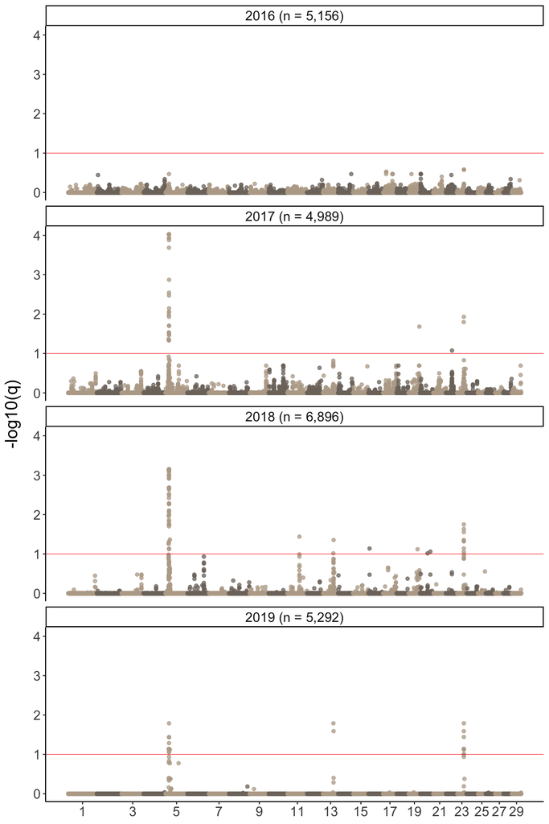

```r
years_gwas %>%
  filter(0.1 > p) %>%
  mutate(year = case_when(year == "2016" ~ "2016 (n = 5,156)",
                          year == "2017" ~ "2017 (n = 4,989)",
                          year == "2018" ~ "2018 (n = 6,896)",
                          year == "2019" ~ "2019 (n = 5,292)")) %>%
  hair_manhattan(y_var = neglog10q,
                 y_lab = "-log10(q)",
                 sigline = 1,
                 color1 = "#b9aa97",
                 color2 = "#7e756d") +
  facet_wrap(~ year,
             nrow = 4,
             scales = "fixed")
```

# Step 2a. Meta-analysis of year-by-year GWAS results

- First, run using year-by-year GWAS summary statistics:

```
srun java -jar source_functions/Metasoft/Metasoft.jar -pvalue_table source_functions/Metasoft/HanEskinPvalueTable.txt -input data/derived_data/metasoft/years/metasoft_in.years.txt -output data/derived_data/metasoft/years/metasoft_out.years.txt -mvalue -mvalue_p_thres 0.01 -log data/derived_data/metasoft/years/metasoft.years.log
```

- Second, run using lambda values calculated in previous run to correct RE2 p-values:
  - `-lambda_mean 1.661412`
  - `-lambda_hetero 0.110889`

```
srun java -jar source_functions/Metasoft/Metasoft.jar -pvalue_table source_functions/Metasoft/HanEskinPvalueTable.txt -input data/derived_data/metasoft/years/metasoft_in.years.txt -output data/derived_data/metasoft/years/metasoft_out.years_adj.txt -mvalue -mvalue_p_thres 0.01 -lambda_mean 1.661412 -lambda_hetero 0.110889 -log data/derived_data/metasoft/years/metasoft.years.log
```

## Diagnostic

- Random effects model pre-genomic control
  - Inflation factor = 1.5247617

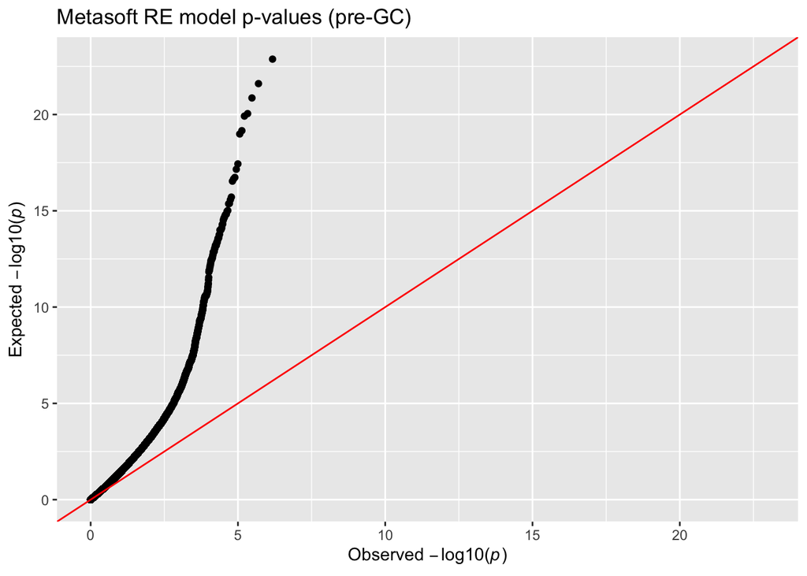

```r
ggqq(years_metasoft$pvalue_re) +
  ggplot2::ggtitle("Metasoft RE model p-values (pre-GC)")
```

- Random effects model post-genomic control
  - Inflation factor = 1

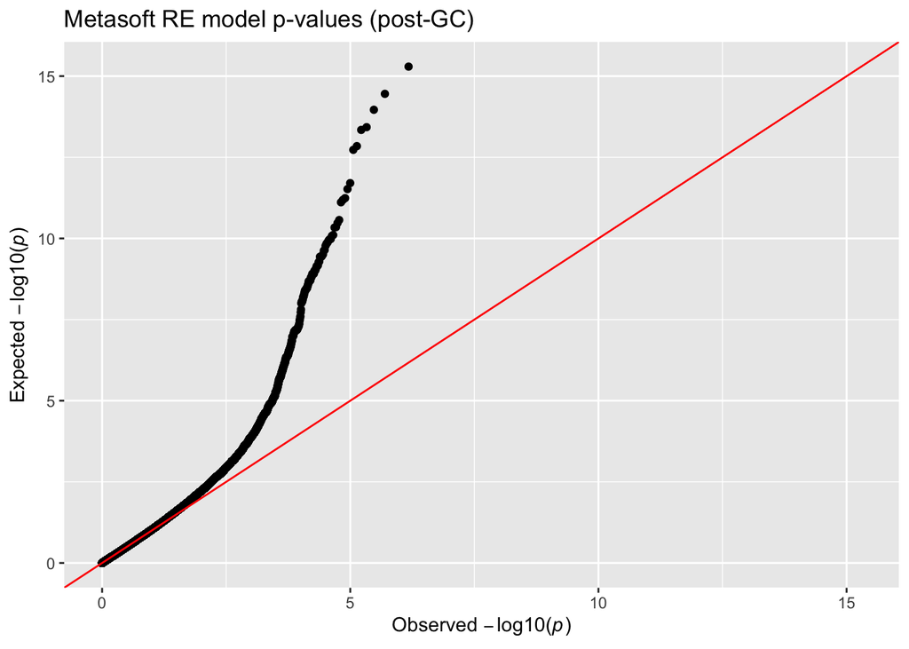

```r
ggqq(years_metasoft$adj_p_re) +
  ggplot2::ggtitle("Metasoft RE model p-values (post-GC)")
```

- Random effects 2 model, p-values adjusted within Metasoft
  - Inflation factor = 0.8877306

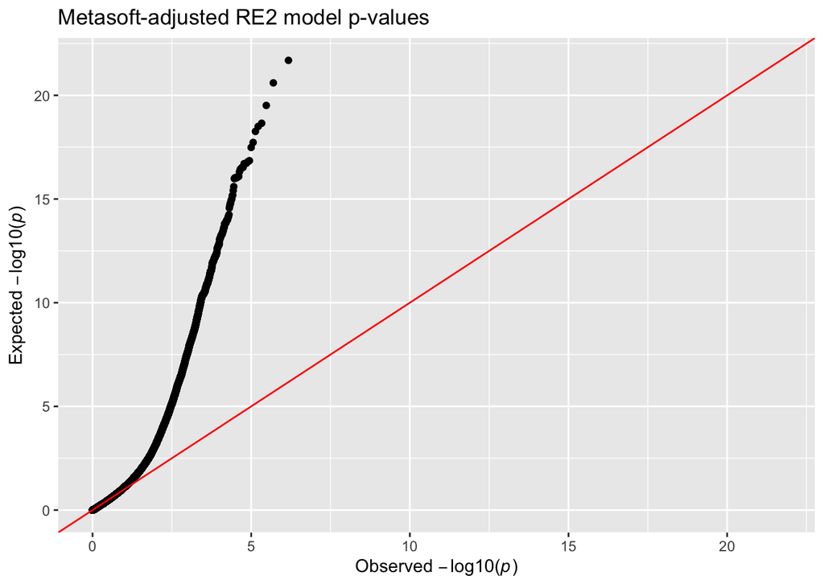

```r
ggqq(years_metasoft$pvalue_re2) +
  ggplot2::ggtitle("Metasoft-adjusted RE2 model p-values")
```

### Should I use meta-analysis results or p-values from SNP1101 using DEBVs?

- What’s the correlation between adjusted RE and adjusted SNP1101 p-values? Between RE2 and adjusted SNP1101 p-values? Between RE2 and adjusted RE p-values?

```r
years_metasoft %>%
  select(chr, pos, RE2 = pvalue_re2, `Adj. RE` = adj_p_re) %>%
  left_join(fixed9_snp1101 %>%
              select(chr, pos, `Adj. SNP1101` = adj_p)) %>%
  select(-chr, -pos) %>%
  corrr::correlate(diagonal = 1) %>%
  rename(`P-value` = rowname)
```

| P-value | RE2 | Adj. RE | Adj. SNP1101 |
| --- | --- | --- | --- |
| RE2 | 1.0000000 | 0.8660594 | 0.6485281 |
| Adj. RE | 0.8660594 | 1.0000000 | 0.6963804 |
| Adj. SNP1101 | 0.6485281 | 0.6963804 | 1.0000000 |

- Correlation between RE and RE2 p-values

```r
years_metasoft %>%
  summarise(Correlation = cor(pvalue_re, pvalue_re2))
```

| Correlation |
| --- |
| 0.8558171 |

## Results

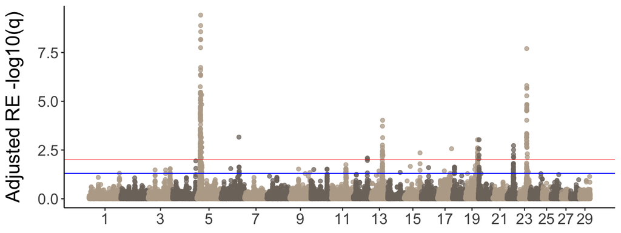

```r
years_metasoft %>%
  filter(0.1 > pvalue_re) %>%
  hair_manhattan(y_var = neglog10q,
                 y_lab = "Adjusted RE -log10(q)",
                 color1 = "#b9aa97",
                 color2 = "#7e756d",
                 sigline = q_fdr1) +
  geom_hline(yintercept = q_fdr5,
             color = "blue")
```

## Cochran’s Q

```r
years_metasoft %>%
  mutate(neglog10q_cq = -log10(qvalue::qvalue(pvalue_q)$qvalues)) %>%
  filter(neglog10q_cq >= q_fdr5)
```

| rsid | number_study | pvalue_re | beta_re | std_re | pvalue_re2 | stat1_re2 | stat2_re2 | i_square | q | pvalue_q | tau_square | pvalues_of_studies_tab_delimitered | mvalues_of_studies_tab_delimitered | p16 | p17 | p18 | p19 | m16 | m17 | m18 | m19 | adj_p_re | neglog10q | chr | pos | neglog10q_cq |
| --- | --- | --- | --- | --- | --- | --- | --- | --- | --- | --- | --- | --- | --- | --- | --- | --- | --- | --- | --- | --- | --- | --- | --- | --- | --- | --- |

```r
years_metasoft %>%
  mutate(neglog10p_cq = -log10(pvalue_q)) %>%
  filter(neglog10p_cq >= 5)
```

| rsid | number_study | pvalue_re | beta_re | std_re | pvalue_re2 | stat1_re2 | stat2_re2 | i_square | q | pvalue_q | tau_square | pvalues_of_studies_tab_delimitered | mvalues_of_studies_tab_delimitered | p16 | p17 | p18 | p19 | m16 | m17 | m18 | m19 | adj_p_re | neglog10q | chr | pos | neglog10p_cq |
| --- | --- | --- | --- | --- | --- | --- | --- | --- | --- | --- | --- | --- | --- | --- | --- | --- | --- | --- | --- | --- | --- | --- | --- | --- | --- | --- |

```r
years_metasoft %>%
  mutate(neglog10p_cq = -log10(pvalue_q)) %>%
  summarise(min(neglog10p_cq), max(neglog10p_cq))
```

| min(neglog10p_cq) | max(neglog10p_cq) |
| --- | --- |
| 8.685898e-07 | 4.327353 |

# Step 2b. Calculate allele frequencies and missingness

```
module load plink/plink-1.90b
srun -c 12 plink --bfile data/raw_data/geno_dump/200924_HairShed.850K.qc --double-id --cow --threads 12 --keep data/derived_data/cojo/years/years.keep.txt --freq --missing --out data/derived_data/cojo/years/years
```

- Calculate allele frequencies and missingness within year-by-year animals

```r
c(2016:2019) %>%
  purrr::map_dfr(~ read_table2(here::here(glue("data/derived_data/gcta_gwas.years/{.x}/pheno.txt")),
                               col_names = FALSE) %>%
                   select(X1, X2)) %>%
  distinct() %>%
  write_tsv(here::here("data/derived_data/cojo/years/years.keep.txt"),
            col_names = FALSE)
```

```
module load plink/plink-1.90b
srun -c 12 plink --bfile data/raw_data/geno_dump/200924_HairShed.850K.qc --double-id --cow --threads 12 --keep data/derived_data/cojo/years/years.keep.txt --freq --missing --make-bed --out data/derived_data/cojo/years/years_subset
```

# Step 3. COJO using GC-adjusted RE1 p-values from Metasoft

- Run COJO using only year-by-year GWAS animals as LD ref

```
srun --account animalsci -p BioCompute,htc4,hpc5 -t 12:00:00 --mem 48G -c 56 source_functions/gcta_1.93.2beta/gcta64 --bfile data/derived_data/cojo/years/years_subset --cojo-file data/derived_data/cojo/years/years_adj.ma --cojo-slct --out data/derived_data/cojo/years/years_subset_adj --threads 56
```

## Selected SNPs

> All manhattan plots below projected on Metasoft results, not results from SNP1101 using DEBVs

### Whole-genome

```r
slct_wg <-
  years_metasoft %>%
  filter(0.1 > adj_p_re) %>%
  left_join(years_jma %>%
              select(chr, pos) %>%
              mutate(clr = TRUE)) %>%
  hair_manhattan(y_var = neglog10q,
                 y_lab = latex2exp::TeX("$-log_{10}(q-value)$"),
                 sigline = q_fdr1,
                 color1 = "#b9aa97",
                 color2 = "#7e756d",
                 highlight = TRUE,
                 highlight_col = clr) +
  geom_hline(yintercept = q_fdr5,
             color = "blue",
             size = 0.5)
```

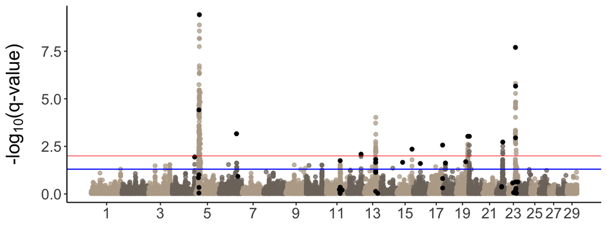

```r
slct_wg
```

- How many COJO SNPs also significant at FDR = 5% in the meta-analysis?

```r
years_jma %>%
  select(chr, pos) %>%
  left_join(years_metasoft %>%
              filter(neglog10q >= q_fdr5) %>%
              select(chr, pos, neglog10q)) %>%
  summarise(`Passing @ FDR = 5%` = sum(!is.na(neglog10q)),
            `New association` = sum(is.na(neglog10q)))
```

| Passing @ FDR = 5% | New association |
| --- | --- |
| 20 | 37 |

- How many COJO SNPs also significant at FDR = 5% in the SNP1101 analysis?

```r
years_jma %>%
  select(chr, pos) %>%
  left_join(fixed9_snp1101 %>%
              filter(neglog10q >= q_fdr5) %>%
              select(chr, pos, neglog10q)) %>%
  summarise(`Passing @ FDR = 5%` = sum(!is.na(neglog10q)),
            `New association` = sum(is.na(neglog10q)))
```

| Passing @ FDR = 5% | New association |
| --- | --- |
| 17 | 40 |

### Chromosome 5

```r
slct_5 <-
  years_metasoft %>%
  filter(chr == 5) %>%
  filter(30000000 >= pos) %>%
  filter(pos >= 10000000) %>%
  mutate(clr = "#b9aa97") %>%
  ggplot(aes(x = pos,
             y = neglog10q,
             color = clr)) +
  geom_point(alpha = 0.75) +
  scale_color_identity() +
  geom_point(data = years_jma %>%
               filter(chr == 5) %>%
               select(chr, pos) %>%
               left_join(years_metasoft %>%
                           select(chr, pos, neglog10q)),
             aes(x = pos,
                 y = neglog10q),
             color = "black",
             fill = "black") +
  scale_x_continuous(breaks = c(10000000, 15000000, 20000000, 25000000, 30000000),
                     labels = c("10 Mb", "15 Mb", "20 Mb", "25 Mb", "30 Mb")) +
  theme_classic() +
  theme(axis.title = element_text(size = 18),
        axis.title.y = element_text(margin = margin(t = 0,
                                                    r = 13,
                                                    b = 0,
                                                    l = 0)),
        axis.text = element_text(size = 14),
        legend.text = element_text(size = 14),
        axis.title.x = element_blank(),
        panel.background = element_rect(fill = "transparent",
                                        colour = NA),
        plot.background = element_rect(fill = "transparent",
                                       colour = NA),
        plot.title = element_text(size = 24,
                                      face = "italic",
                                      margin = margin(t = 0,
                                                      r = 0,
                                                      b = 13,
                                                      l = 0))) +
  labs(x = NULL,
       y = latex2exp::TeX("$-log_{10}(q-value)$"),
       title = NULL) +
  geom_hline(yintercept = q_fdr1,
             color = "red",
             size = 0.5) +
  geom_hline(yintercept = q_fdr5,
             color = "blue",
             size = 0.5)
```

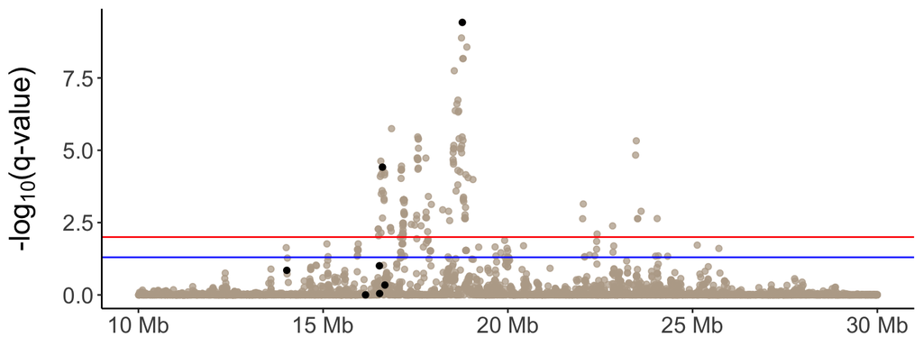

```r
slct_5
```

### Chromosome 23

```r
slct_23 <-
  years_metasoft %>%
  filter(chr == 23) %>%
  filter(pos > 20000000) %>%
  filter(50000000 > pos) %>%
  mutate(clr = "#b9aa97") %>%
  ggplot(aes(x = pos,
             y = neglog10q,
             color = clr)) +
  geom_point(alpha = 0.75) +
  scale_color_identity() +
  geom_point(data = years_jma %>%
               filter(chr == 23) %>%
               select(chr, pos) %>%
               left_join(years_metasoft %>%
                           select(chr, pos, neglog10q)),
             aes(x = pos,
                 y = neglog10q),
             color = "black",
             fill = "black") +
  scale_x_continuous(breaks = c(20000000, 25000000, 30000000, 35000000, 40000000, 45000000, 50000000),
                     labels = c("20 Mb", "25 Mb", "30 Mb", "35 Mb", "40 Mb", "45 Mb", "50 Mb")) +
  theme_classic() +
  theme(axis.title = element_text(size = 18),
        axis.title.y = element_text(margin = margin(t = 0,
                                                    r = 13,
                                                    b = 0,
                                                    l = 0)),
        axis.text = element_text(size = 14),
        legend.text = element_text(size = 14),
        axis.title.x = element_blank(),
        panel.background = element_rect(fill = "transparent",
                                        colour = NA),
        plot.background = element_rect(fill = "transparent",
                                       colour = NA),
        plot.title = element_text(size = 24,
                                      face = "italic",
                                      margin = margin(t = 0,
                                                      r = 0,
                                                      b = 13,
                                                      l = 0))) +
  labs(x = NULL,
       y = latex2exp::TeX("$-log_{10}(q-value)$"),
       title = NULL) +
  geom_hline(yintercept = q_fdr1,
             color = "red",
             size = 0.5) +
  geom_hline(yintercept = q_fdr5,
             color = "blue",
             size = 0.5)
```

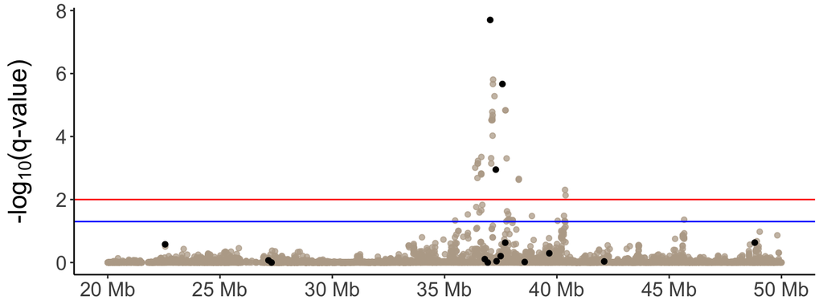

```r
slct_23
```

### Panel figure

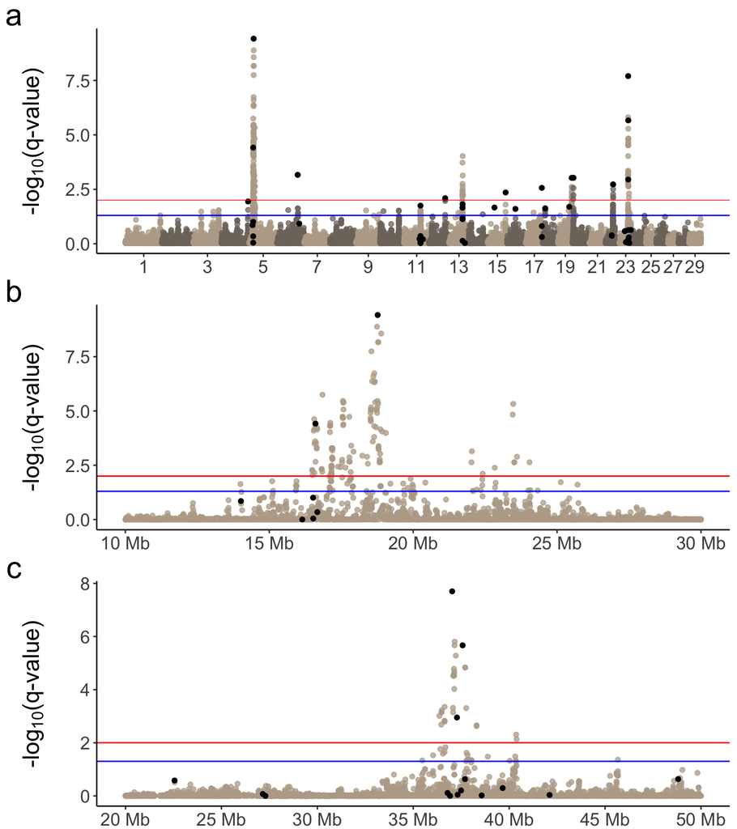

```r
slct_wg/slct_5/slct_23 + plot_annotation(tag_levels = c("a")) &
  theme(plot.tag = element_text(size = 24),
        plot.margin = margin(t = 0, b = 0, l = 0.75, r = 1, unit = "mm"))
```

```r
ggsave(filename = here::here("figures/cojo/metasoft.q.cojo_panel.png"), height = 9, width = 8)
```